# Notes

# Unit 1

### 1) **Characteristics of System**

- **Organization**: Structure and order that arranges components to achieve objectives.
- **Interaction**: Manner in which components work together.
- **Interdependence**: Subsystems depend on each other for functionality.
- **Integration**: Unifies components into a cohesive whole.
- **Central Objective**: Defined purpose or goal.

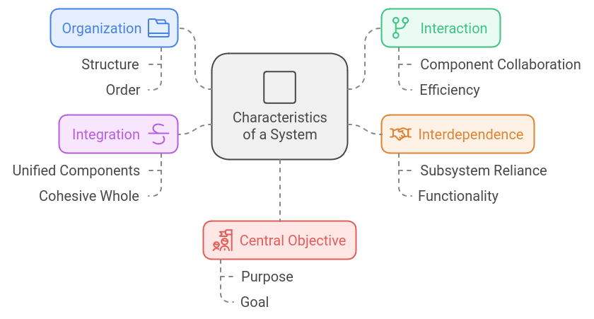

### 2) **Elements of a System**

- **Inputs and Outputs**: Data entering and leaving the system.
- **Processor(s)**: Transform input into output.
- **Control**: Decision-making components managing system behavior.
- **Feedback**: Helps maintain system balance; can be positive or negative.
- **Environment**: External factors influencing the system.
- **Boundaries and Interface**: Define the scope and interaction with other systems.

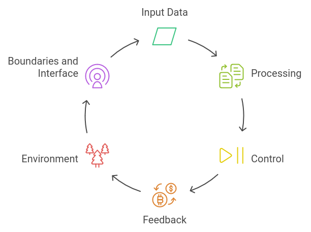

### 3) **Concept of System Analyst**

#### **Definition**:

A system analyst is a professional with technical and interpersonal skills who guides system development to align with organizational goals.

#### **Roles**:

- Understand user requirements using fact-finding techniques.
- Prioritize and document requirements.
- Suggest and implement flexible solutions.
- Provide detailed specifications for users and programmers.
- Ensure modular system design.
- Facilitate system evaluation and updates.

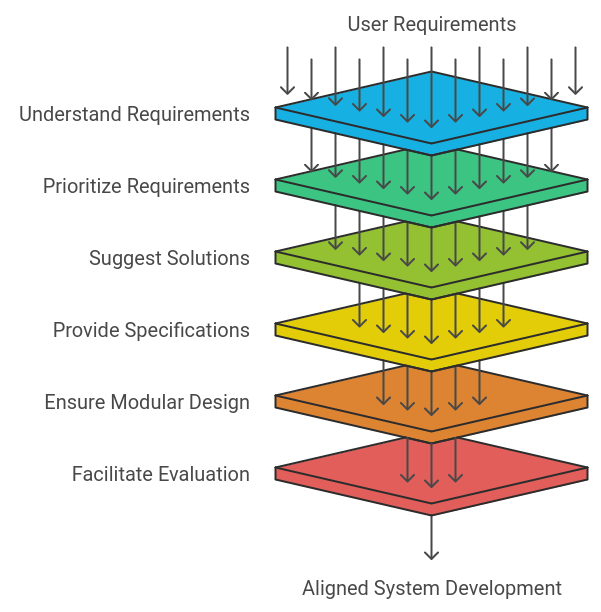

#### **Attributes**:

- **Interpersonal Skills**: Communication, leadership, and motivation.
- **Analytical Skills**: Problem-solving, trade-off analysis, and curiosity.
- **Management Skills**: Project management, change/risk management.
- **Technical Skills**: Knowledge of computers, design tools, and emerging technologies.

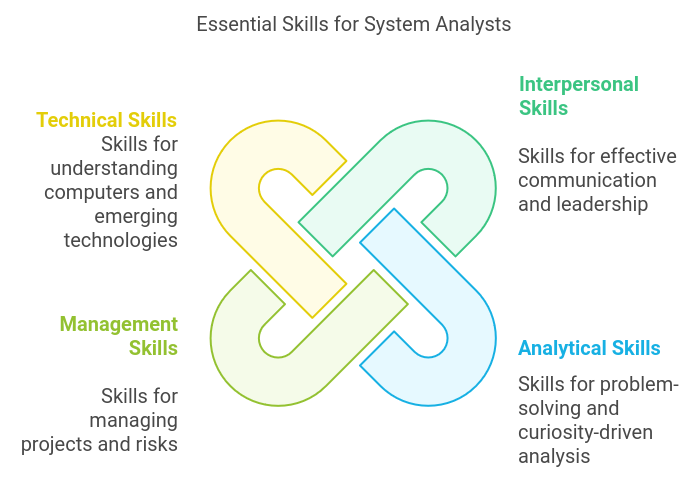

### 4) **Concept of Application Development Portfolio (ADP)**

- **Definition**: ADP refers to a set of proposed or approved projects under development that focus on:
  - Solving problems (e.g., reducing data entry errors).
  - Capitalizing on opportunities (e.g., offering discounts to frequent customers).
  - Responding to directives (e.g., legal compliance).

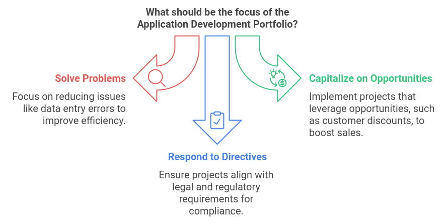

### 5) **5 C’s**

- **Capability**: Speed, volume processing, and information retrieval.
- **Control**: Accuracy, consistency, and security.
- **Communication**: Faster information flow and integration of business areas.
- **Cost**: Cost monitoring and reduction.
- **Competitiveness**: Enhancing customer relationships, locking out competitors, and enabling product development.

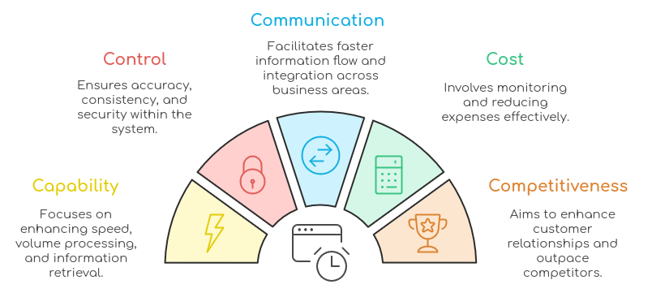